# Method Comparison

Can LUO

Coverage probability is an important operating characteristic of methods for constructing interval estimates, particularly confidence intervals.

Idealy, a 95% confidence interval will capture the population parameter of interest in 95% of samples. One can also calculate 80% or 90% confidence intervals. In general, an X% confidence interval should capture the population parameter of interest in X% of samples.

However, not all methods are equally good! Let’s perform a 2 × 4 × 2 factorial simulation study to compare the coverage probability of various methods of calculating 90% confidence intervals.

Three factors in the experiment

1.True, underlying distribution + standard normal (for better to MM with gamma, I shift standard normal to N(4,1) in the simulation) + gamma(shape = 1.4, scale = 3) 2.Model + method of moments with normal + method of moments with gamma + kernel density estimation bootstrap 3.Parameter of interest + sample min (1st order statistic) + median

Other settings in the experiment that will not change are:

- Sample size, N = 201
- Outside the loop estimation

# 1 Simulation result

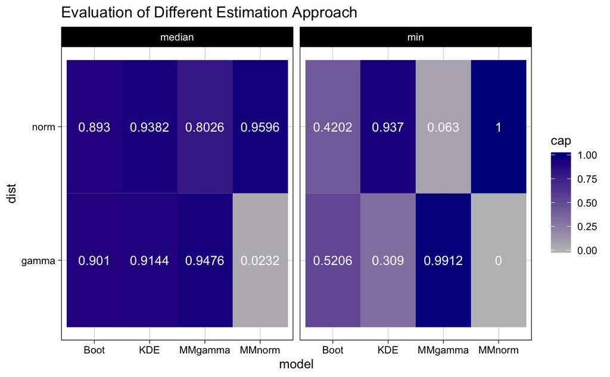

# 2 Evaluation

## 2.1 method of moment

This approach can be very accurate and has high likelihood to capture the interested , if the fitting model is appropriate.

Nevertheless,when we choose inappropriate fitting model, the accuracy of estimation can not be garenteed.

When we use MMnorm model to estimate sample minimum gamma of distribution, the coverage probability is 0, because gamma distribution relies on positive value while normal distribution produces negative values .

When we apply MMgamma model to capture the median of normal distribution , it has high coverage probability, because in this case the estimated distribution is N(4,1), the median value is greater than 0, if the median value is less than 0, the MMgamma model will fail.

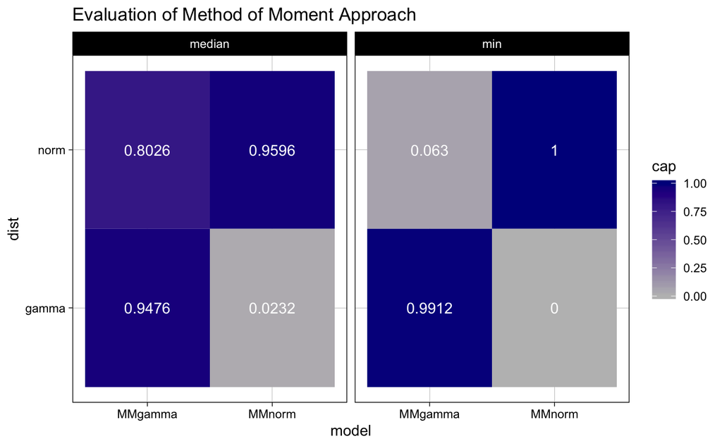

> thoughts: An appropriate model is critical to MM approach . If the model is wrongly chosen, the result will be like a roller coaster.

## 2.2 KDE

kernal density estimation works well for sample median of normal and gamma distribution as well as minimum of normal distribution. However, it doesn’t work well for minimum of gamma distribution.

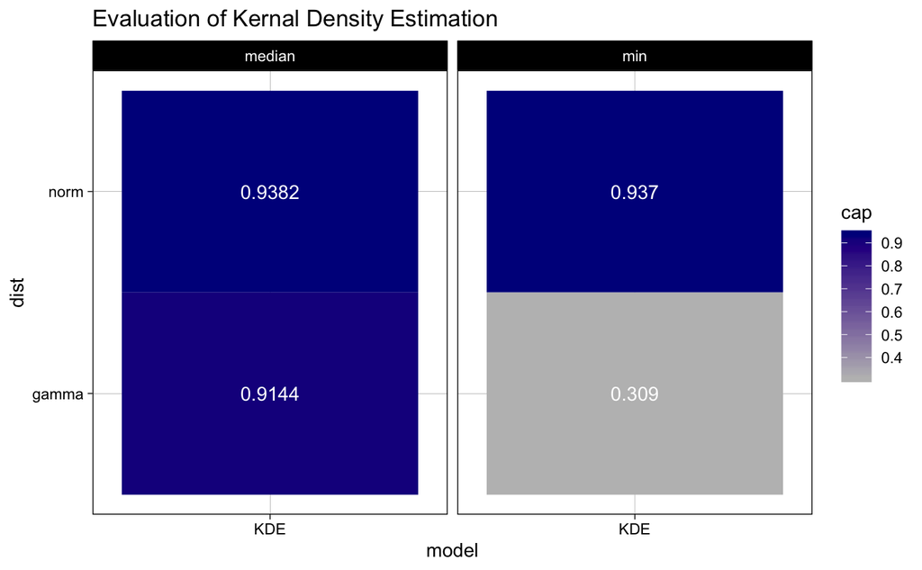

```r
kde<-settings %>%
  filter(model=='KDE')
ggplot(kde, aes(y=dist, x=model)) +
  geom_tile(aes(fill = cap))+
  geom_text(aes(label=cap),col='white')+
  scale_fill_gradient(high = "darkblue",low='gray')+
  facet_wrap(~par.int)+
  theme_linedraw()+
  labs(title='Evaluation of Kernal Density Estimation')
```

Coverage probability for sample minimum of gamma distribution is pretty low, why is that?

Fistly let’s draw a zipper plot to show the capture result.

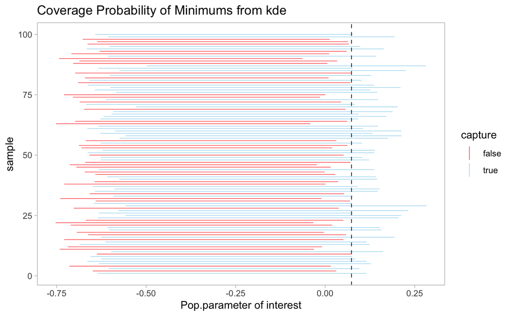

In the zipper plot, we can see that most of the red lines, which mean failure to capture the minimum, are less the true parameter. This is because of the nature of kernal density estimation: smoothen.

The essential part of KDE is choosing a kernal to ‘smoothen’ the density curve.

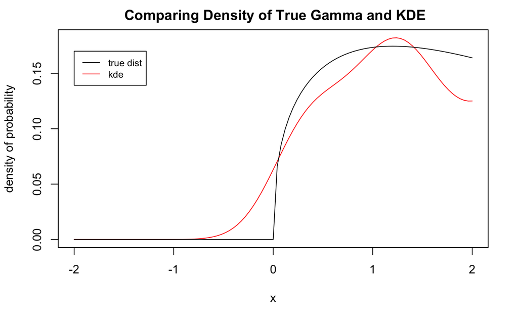

We can see that when x<0, density of true gamma is 0 while the density of KDE distribution is greater than 0, because we’ve applied gaussian kernal to modify the distribution. When we do simulation from KDE, the minimum can propbaly be less than 0, that’s why we can not always capture the true minimum .

> thoughts: kernal density estimation is a good way to smoothen the density curve, and the trade-off is that it might lost some significant detail of the distribution.

## 2.3 bootstrap

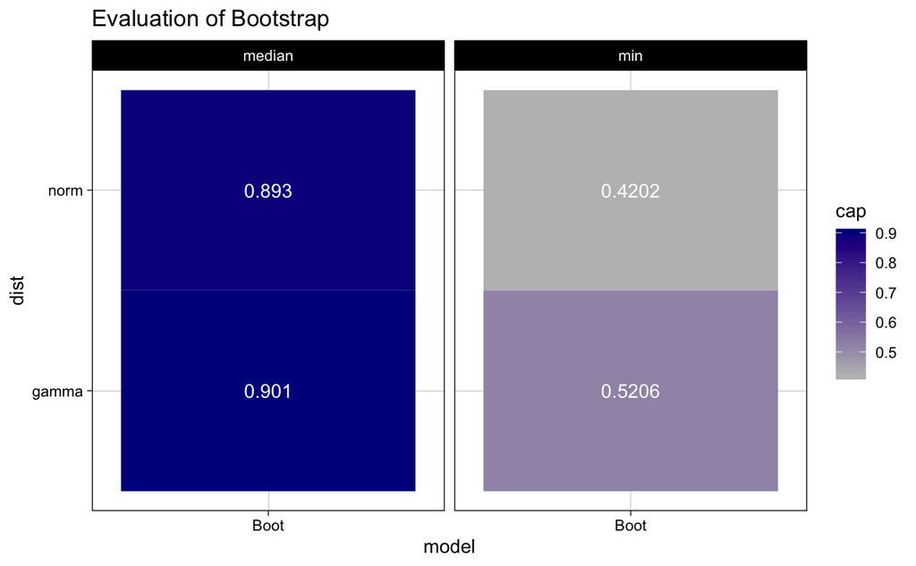

We found that the coverage probability for median is great, but for minimum is so low. Why is that?

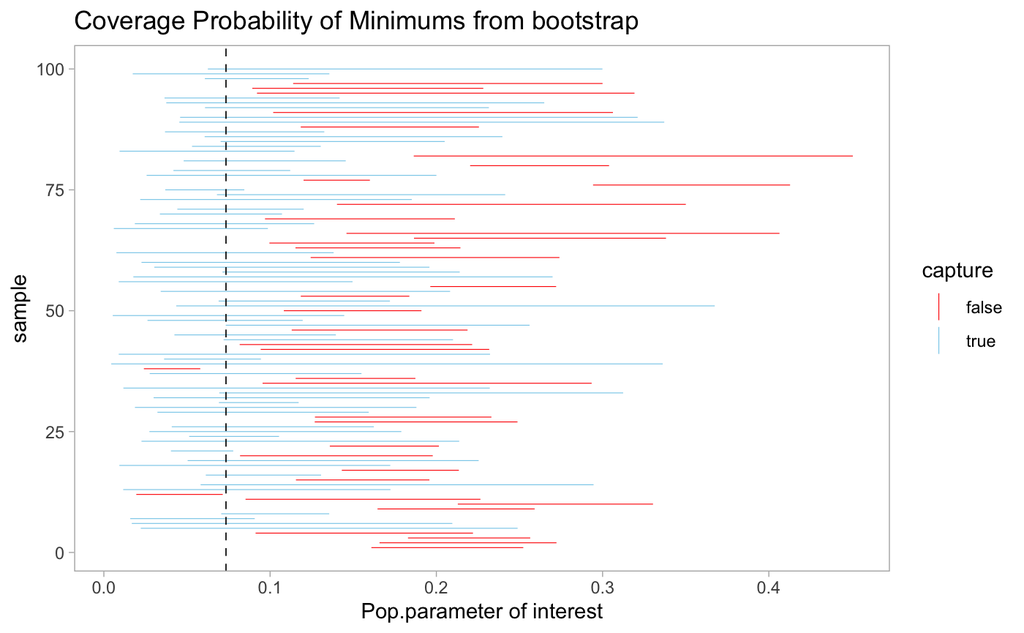

There are two main obstructs for bootstrap to capture the minimum:

1. If the initial plug-in data excludes the true minimum, it can not capture the true minimum.
2. Even if the initial plug-in data includes the true minimum, after bootstrap the simulative distrobution might exclude the true minimum.

> thoughts: the initial data sample has main influence on bootstrap approach.

# 3 conclusion

1. MM is a good approach to estimate unknown distribution,when we have the confidence about the fitting model.
2. KDE can smoothen the density curve, but it is not perfectly "faithful’ to true distribution.
3. Bootstrap relies much on the initial plug-in sample. So it is not good for estimating the extreme value (maximum or minimum).